# PracticalMLAssignment

Socrates Rajkumar Nachiappan

June 18, 2015

### The data comes from this URL:

http://groupware.les.inf.puc-rio.br/har

### The project comes with the training set data and a testing set data as per the assignment page. The training data is available here:

https://d396qusza40orc.cloudfront.net/predmachlearn/pml-training.csv

### The test data is available here:

https://d396qusza40orc.cloudfront.net/predmachlearn/pml-testing.csv

## Libraries to load:

```r
library(caret)
library(doParallel)
set.seed(20150125)
```

## Load training data:

download.file(‘https://d396qusza40orc.cloudfront.net/predmachlearn/pml-training.csv’, ‘pml-training.csv’)

download.file(‘https://d396qusza40orc.cloudfront.net/predmachlearn/pml-testing.csv’,‘pml-test.csv’ )

## Cleaning up the data:

Convert all blanks, ‘#DIV/0’ and ‘NA’ values to ‘NA’.

```r
trainingSrc   <- read.csv('pml-training.csv', na.strings=c("NA","#DIV/0!", ""))

testSrc       <- read.csv('pml-test.csv' , na.strings=c("NA", "#DIV/0!", ""))
```

```r
goodVars    <- which((colSums(!is.na(trainingSrc)) >= 0.6*nrow(trainingSrc)))

trainingSrc <- trainingSrc[,goodVars]

testSrc     <- testSrc[,goodVars]
```

The random forests will be used and in order to do so, some fixes needs to be done.

```r
## remove problem id

testSrc <- testSrc[-ncol(testSrc)]


## fix factor levels

testSrc$new_window <- factor(testSrc$new_window, levels=c("no","yes"))

## Remove non relevant columns like X and cvtd_timestamp colums from the dataset,

trainingSrc <- trainingSrc[,-c(1,5)]

testSrc     <- testSrc[,-c(1,5)]
```

Partition the data into Training and test sets:

So dividing data as 60% training and 40% testing set.

```r
inTraining  <- createDataPartition(trainingSrc$classe, p = 0.6, list = FALSE)

training    <- trainingSrc[inTraining, ]

testing     <- trainingSrc[-inTraining, ]
```

### Random Forest:

```r
#The outcome variable is class and other columns are in data dataframe.

class <- training$classe

data  <- training[-ncol(training)]
```

Parallel Random Forest algorithm is used to fit the model.

Note: that for random forests there is no need for cross-validation to get an unbiased estimate of the test set error. It is estimated internally during the fitting process.

```r
registerDoParallel()

rf <- train(data, class, method="parRF",

    tuneGrid=data.frame(mtry=3),

    trControl=trainControl(method="none"))
## Loading required package: randomForest

rf
```

```
## Parallel Random Forest
##
## 11776 samples
##    57 predictor
##     5 classes: 'A', 'B', 'C', 'D', 'E'
##
## No pre-processing
## Resampling: None
```

Plot the importance of the model variables:

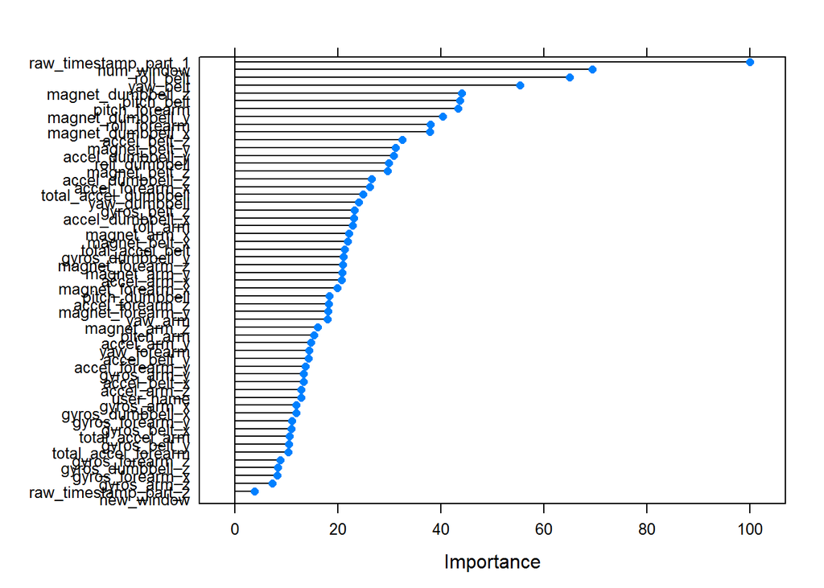

```r
plot(varImp(rf))
```

### Confusion matrix:

Here we are predict on testing set and generating the confusion matrix for the same.

```r
testingPredictions <- predict(rf, newdata=testing)

confMatrix <- confusionMatrix(testingPredictions,testing$classe)

confMatrix
```

```
## Confusion Matrix and Statistics
##
##           Reference
## Prediction    A    B    C    D    E
##          A 2230    1    0    0    0
##          B    2 1516    9    0    0
##          C    0    1 1357   17    0
##          D    0    0    2 1269    3
##          E    0    0    0    0 1439
##
## Overall Statistics
##
##                Accuracy : 0.9955
##                  95% CI : (0.9938, 0.9969)
##     No Information Rate : 0.2845
##     P-Value [Acc > NIR] : < 2.2e-16
##
##                   Kappa : 0.9944
##  Mcnemar's Test P-Value : NA
##
## Statistics by Class:
##
##                      Class: A Class: B Class: C Class: D Class: E
## Sensitivity            0.9991   0.9987   0.9920   0.9868   0.9979
## Specificity            0.9998   0.9983   0.9972   0.9992   1.0000
## Pos Pred Value         0.9996   0.9928   0.9869   0.9961   1.0000
## Neg Pred Value         0.9996   0.9997   0.9983   0.9974   0.9995
## Prevalence             0.2845   0.1935   0.1744   0.1639   0.1838
## Detection Rate         0.2842   0.1932   0.1730   0.1617   0.1834
## Detection Prevalence   0.2843   0.1946   0.1752   0.1624   0.1834
## Balanced Accuracy      0.9995   0.9985   0.9946   0.9930   0.9990
```

Let’s have a look at the accuracy

```r
confMatrix$overall[1]
```

```
##  Accuracy
## 0.9955391
```

Based on this, the results have come out good and it is more then 99.54%.

Submission results of Test Set

```r
pml_write_files = function(x){

  n = length(x)

  for(i in 1:n){

    filename = paste0("problem_id_",i,".txt")

    write.table(x[i],file=filename,quote=FALSE,row.names=FALSE,col.names=FALSE)

  }

}



answers <- predict(rf, testSrc)



pml_write_files(answers)
```

The problem_id_1 till problem_id_20 files were generated.